# Úkol 1

2025-20-01

```r
xlsx_path <- "D:/pavli/Dokumenty/git/vyberove-setreni/ukol1/Vysky.xlsx"
#xlsx_path <- "C:/Users/pavli/Documents/git/vyberove-setreni/ukol1/Vysky.xlsx"

df <- read_excel(xlsx_path, col_names = FALSE, skip = 2)

pop_heights <- as.numeric(df[[2]])
pop_heights <- c(pop_heights, 172)

pop_mean <- mean(pop_heights)
N <- length(pop_heights)
```

# Pravděpodobnostní rozdělení výběrového průměru

## 1) a 4)

Pravděpodobnostní rozdělení (pravděpodobnostní a distribuční funkci) výběrového průměru výšky studentů pro rozsahy výběru n=3,4,5 pro prostý náhodný výběr bez vracení. Graficky porovnejte pravděpodobnostní rozdělení pro různé rozsahy výběru.

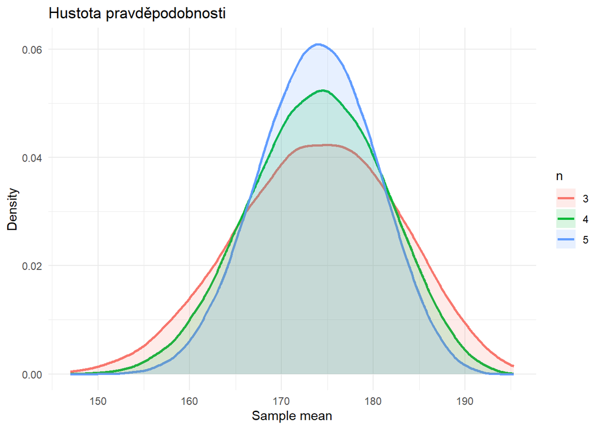

```r
ns <- c(3, 4, 5)

means_list <- lapply(ns, function(n) as.numeric(combn(pop_heights, n, FUN = mean)))
names(means_list) <- as.character(ns)

means_df <- do.call(rbind, lapply(names(means_list), function(n) {
    data.frame(mean = means_list[[n]], n = factor(n))
}))

x_grid <- seq(min(means_df$mean), max(means_df$mean), length.out = 512)

pdf_df <- do.call(rbind, lapply(names(means_list), function(n) {
    m <- means_list[[n]]
    d <- density(m, from = min(x_grid), to = max(x_grid), n = length(x_grid))
    data.frame(x = d$x, density = d$y, n = factor(n))
}))

cdf_df <- do.call(rbind, lapply(names(means_list), function(n) {
    m <- means_list[[n]]
    ec <- ecdf(m)
    data.frame(x = x_grid, cdf = ec(x_grid), n = factor(n))
}))

ggplot(pdf_df, aes(x = x, y = density, color = n, fill = n)) +
    geom_line(size = 1) +
    geom_ribbon(aes(ymin = 0, ymax = density), alpha = 0.15, color = NA) +
    labs(title = "Hustota pravděpodobnosti", x = "Sample mean", y = "Density", color = "n", fill = "n") +
    theme_minimal()
```

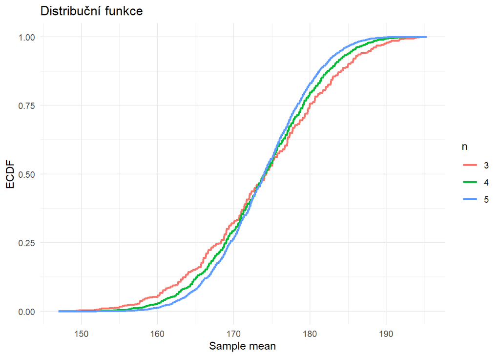

```r
ggplot(cdf_df, aes(x = x, y = cdf, color = n)) +
    geom_line(size = 1) +
    labs(title = "Distribuční funkce", x = "Sample mean", y = "ECDF", color = "n") +
    theme_minimal()
```

## 2)

Pro rozsahy výběru n=3,4,5 vypočtěte střední hodnotu a rozptyl výběrového průměru výšky studentů v sledované populaci. Jsou výběrové průměry nestranné odhady populačního průměru? Vypočtěte vychýlení (bias) pro tyto odhady.

```r
ns <- sort(unique(as.character(means_df$n)))
results <- data.frame(n = integer(), mean = numeric(), var = numeric(), bias = numeric(), stringsAsFactors = FALSE)

for (n_chr in ns) {
    n_num <- as.numeric(n_chr)
    means_n <- means_df$mean[as.character(means_df$n) == n_chr]
    emp_mean <- mean(means_n)
    theo_var <- var(means_n) * (length(means_n) - 1)/length(means_n)
    bias <- emp_mean - pop_mean
    results <- rbind(results, data.frame(n = n_num, mean = emp_mean, var = theo_var, bias = bias))
}

kable(results, digits = 6)
```

| n | mean | var | bias |
| --- | --- | --- | --- |
| 3 | 173.8947 | 74.41387 | 0 |
| 4 | 173.8947 | 52.32225 | 0 |
| 5 | 173.8947 | 39.06728 | 0 |

## 3)

Posuďte variabilitu odhadů pomocí vhodných popisných statistikami (variační koeficient, 1. a 9. decil, 1. a 3. kvartil, variační/mezikvartilové rozpětí).

```r
ns <- sort(unique(as.character(means_df$n)))
var_stats <- data.frame(n = integer(), cv = numeric(), decil1 = numeric(), decil9 = numeric(), q1 = numeric(), q3 = numeric(), iqr = numeric(), R = numeric(), stringsAsFactors = FALSE)

for (n_chr in ns) {
    n_num <- as.numeric(n_chr)
    means_n <- means_df$mean[as.character(means_df$n) == n_chr]
    mu <- mean(means_n)
    sd_n <- sd(means_n)
    cv <- sd_n / mu
    decs <- quantile(means_n, probs = c(0.1, 0.9), names = FALSE)
    qs <- quantile(means_n, probs = c(0.25, 0.75), names = FALSE)
    iqr_n <- qs[2] - qs[1]
    R <- max(means_n) - min(means_n)
    var_stats <- rbind(var_stats, data.frame(n = n_num, cv = cv, decil1 = decs[1], decil9 = decs[2], q1 = qs[1], q3 = qs[2], iqr = iqr_n, R = R))
}

kable(var_stats, digits = 6)
```

| n | cv | decil1 | decil9 | q1 | q3 | iqr | R |
| --- | --- | --- | --- | --- | --- | --- | --- |
| 3 | 0.049632 | 162.6667 | 185.00 | 168.3333 | 180.0 | 11.66667 | 48.33333 |
| 4 | 0.041602 | 164.5000 | 183.25 | 169.0000 | 179.0 | 10.00000 | 43.00000 |
| 5 | 0.035945 | 165.6000 | 182.00 | 169.6000 | 178.4 | 8.80000 | 39.40000 |

# Pravděpodobnostní rozdělení relativní četnosti

```r
my_height <- 172

K <- sum(pop_heights > my_height)
ration_height <- K / N
print(ration_height)
```

```
## [1] 0.5263158
```

## 1)

Pravděpodobnostní rozdělení (pravděpodobnostní a distribuční funkci) výběrové relativní četnosti pro rozsahy výběru n=3,4,5 pro prostý náhodný výběr bez vracení.

```r
ns <- c(3,4,5)
counts_df <- data.frame()
rel_df <- data.frame()
for (n in ns) {
    ks <- 0:n
    probs <- dhyper(ks, m = K, n = N - K, k = n)
    cdfv <- cumsum(probs)
    counts_df <- rbind(counts_df, data.frame(n = n, k = ks, prob = probs, cdf = cdfv))
    rel_df <- rbind(rel_df, data.frame(n = n, k=ks, rel = ks / n, prob = probs, cdf = cdfv))
}

kable(rel_df[rel_df$n == 3, c("k",'rel','prob','cdf')], digits = 6)
```

| k | rel | prob | cdf |
| --- | --- | --- | --- |
| 0 | 0.000000 | 0.086687 | 0.086687 |
| 1 | 0.333333 | 0.371517 | 0.458204 |
| 2 | 0.666667 | 0.417957 | 0.876161 |
| 3 | 1.000000 | 0.123839 | 1.000000 |

```r
kable(rel_df[rel_df$n == 4, c("k",'rel','prob','cdf')], digits = 6)
```

|  | k | rel | prob | cdf |
| --- | --- | --- | --- | --- |
| 5 | 0 | 0.00 | 0.032508 | 0.032508 |
| 6 | 1 | 0.25 | 0.216718 | 0.249226 |
| 7 | 2 | 0.50 | 0.417957 | 0.667183 |
| 8 | 3 | 0.75 | 0.278638 | 0.945820 |
| 9 | 4 | 1.00 | 0.054180 | 1.000000 |

```r
kable(rel_df[rel_df$n == 5, c("k",'rel','prob','cdf')], digits = 6)
```

|  | k | rel | prob | cdf |
| --- | --- | --- | --- | --- |
| 10 | 0 | 0.0 | 0.010836 | 0.010836 |
| 11 | 1 | 0.2 | 0.108359 | 0.119195 |
| 12 | 2 | 0.4 | 0.325077 | 0.444272 |
| 13 | 3 | 0.6 | 0.371517 | 0.815789 |
| 14 | 4 | 0.8 | 0.162539 | 0.978328 |
| 15 | 5 | 1.0 | 0.021672 | 1.000000 |

## 2)

Pro rozsahy výběru n=3,4,5 vypočtěte střední hodnotu a rozptyl výběrové relativní četnosti. Jsou výběrové průměry nestranné odhady populační relativní četnosti? Vypotěte vychýlení (bias) pro tyto odhady.

```r
res_prop <- data.frame(n = integer(), mean_rel = numeric(), var_rel = numeric(), bias = numeric(), stringsAsFactors = FALSE)
for (n in ns) {
    d <- rel_df[rel_df$n == n, ]
    mean_rel <- sum(d$rel * d$prob)
    second <- sum((d$rel^2) * d$prob)
    var_rel <- second - mean_rel^2
    p <- K / N
    bias <- mean_rel - p
    res_prop <- rbind(res_prop, data.frame(n = n, mean_rel = mean_rel, var_rel = var_rel, bias = bias))
}
kable(res_prop, digits = 6)
```

| n | mean_rel | var_rel | bias |
| --- | --- | --- | --- |
| 3 | 0.526316 | 0.073869 | 0 |
| 4 | 0.526316 | 0.051939 | 0 |
| 5 | 0.526316 | 0.038781 | 0 |

Bias je velmi malý, odhady jsou tedy nestranné.

## 3)

Graficky porovnejte pravděpodobnostní rozdělení pro různé rozsahy výběru.

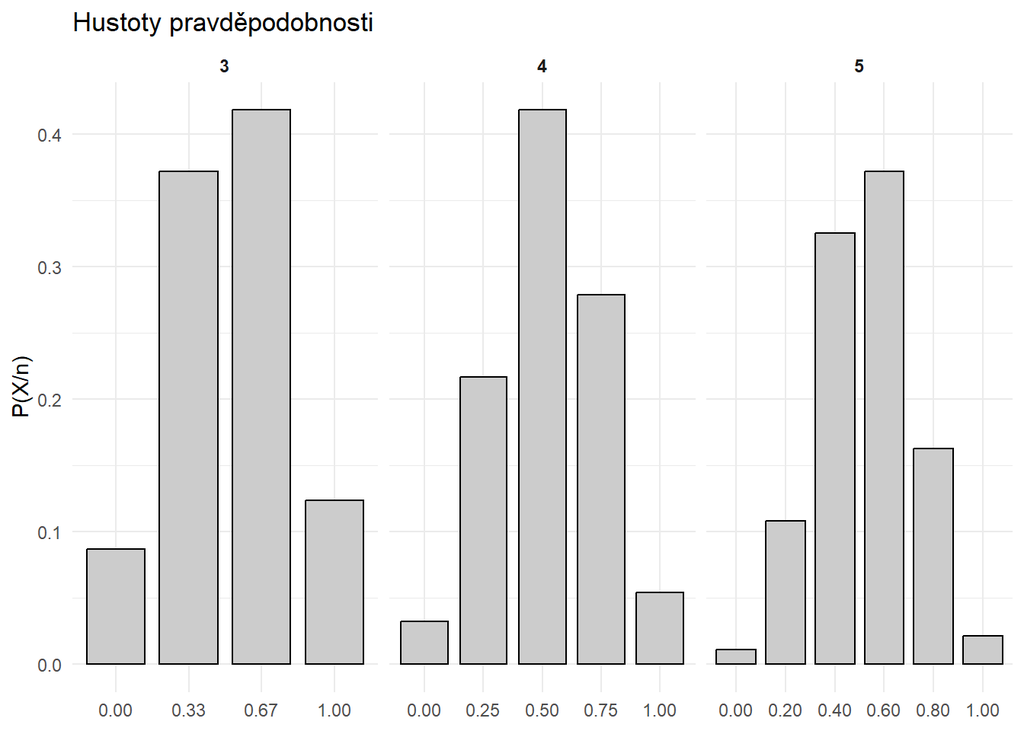

```r
rel_df <- rel_df %>% arrange(n, rel)
rel_df <- rel_df %>% mutate(rel = as.numeric(rel))
rel_df <- rel_df %>% group_by(n) %>% mutate(rel_lab = sprintf("%.2f", rel)) %>% ungroup()

ggplot(rel_df, aes(x = rel_lab, y = prob)) +
    geom_col(fill = 'grey80', color = 'black', width = 0.8) +
    facet_wrap(~ n, nrow = 1, scales = 'free_x') +
    labs(title = 'Hustoty pravděpodobnosti', x = NULL, y = 'P(X/n)') +
    theme_minimal() +
    theme(strip.text = element_text(face = 'bold'),
                axis.text.x = element_text(angle = 0))
```

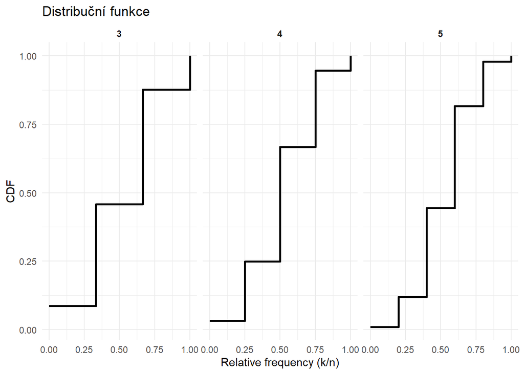

```r
ggplot(rel_df, aes(x = rel, y = cdf)) +
    geom_step(direction = 'hv', size = 1) +
    facet_wrap(~ n, nrow = 1, scales = 'free_x') +
    scale_x_continuous(labels = function(x) sprintf("%.2f", x)) +
    labs(title = 'Distribuční funkce', x = 'Relative frequency (k/n)', y = 'CDF') +
    theme_minimal() +
    theme(strip.text = element_text(face = 'bold'))
```

## 4)

Určete pravděpodobnostní rozdělení (pravděpodobnostní a distribuční funkci) počtu studentů, kteří jsou vyšší než vy, pro rozsahy výběru n=3,4,5 pro prostý náhodný výběr bez vracení. O jaké rozdělení se jedná?

**Počet studentů vyšších než já má hypergeometrické rozdělení.**

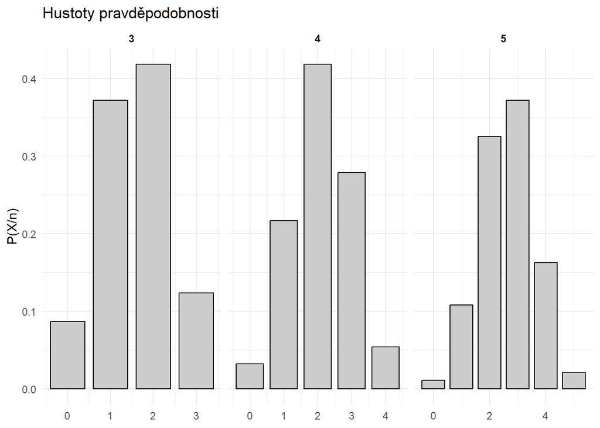

```r
rel_df <- rel_df %>% arrange(n, rel)
rel_df <- rel_df %>% mutate(rel = as.numeric(rel))
rel_df <- rel_df %>% group_by(n) %>% mutate(rel_lab = sprintf("%.2f", rel)) %>% ungroup()

ggplot(rel_df, aes(x = k, y = prob)) +
    geom_col(fill = 'grey80', color = 'black', width = 0.8) +
    facet_wrap(~ n, nrow = 1, scales = 'free_x') +
    labs(title = 'Hustoty pravděpodobnosti', x = NULL, y = 'P(X/n)') +
    theme_minimal() +
    theme(strip.text = element_text(face = 'bold'),
                axis.text.x = element_text(angle = 0))
```

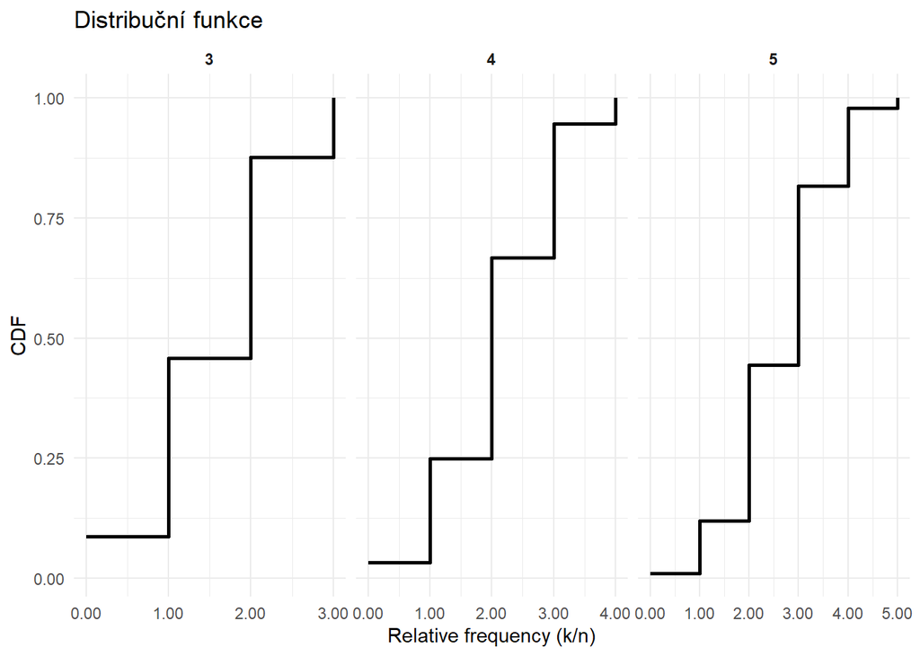

```r
ggplot(rel_df, aes(x = k, y = cdf)) +
    geom_step(direction = 'hv', size = 1) +
    facet_wrap(~ n, nrow = 1, scales = 'free_x') +
    scale_x_continuous(labels = function(x) sprintf("%.2f", x)) +
    labs(title = 'Distribuční funkce', x = 'Relative frequency (k/n)', y = 'CDF') +
    theme_minimal() +
    theme(strip.text = element_text(face = 'bold'))
```